# Multiple Linear Regression: Introduction

## Multiple linear regression model

In simple linear regression, we have one dependent variable ($y$) and one independent variable ($x$). In multiple linear regression, we have one dependent variable ($y$) and several independent variables ($x_1,x_2, \ldots,x_k$).

- The multiple linear regression model, for the **population**, can be expressed as
  $$Y=\beta_0+\beta_1 x_1 +\beta_2
  x_2+\ldots+\beta_kx_k+ \epsilon$$
  where $\epsilon$ is the error term.
- The corresponding least square estimate, from the **sample**, of this multiple linear regression model is given by
  $$\hat{y}=b_0+b_1 x_1+b_2
  x_2+\ldots+b_k x_k$$
- The coefficient $b_0$ (or $\beta_0$) represents the $y$-intercept, that is, the value of $y$ when $x_1=x_2= \ldots=x_k=0$. The coefficient $b_i$ (or $\beta_i$) $(i=1, \ldots, k)$ is the partial slope of $x_i$, holding all other $x$’s fixed. So $b_i$ (or $\beta_i$) tells us the change in $y$ for a unit increase in $x_i$, holding all other $x$’s fixed.

## Example: used cars (cont.)

The table below displays data on Age, Miles and Price for a sample of cars of a particular make and model.

| Price ($y$) | Age ($x_1$) | Miles ($x_2$) |
| --- | --- | --- |
| 85 | 5 | 57 |
| 103 | 4 | 40 |
| 70 | 6 | 77 |
| 82 | 5 | 60 |
| 89 | 5 | 49 |
| 98 | 5 | 47 |
| 66 | 6 | 58 |
| 95 | 6 | 39 |
| 169 | 2 | 8 |
| 70 | 7 | 69 |
| 48 | 7 | 89 |

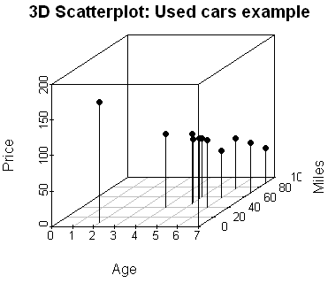

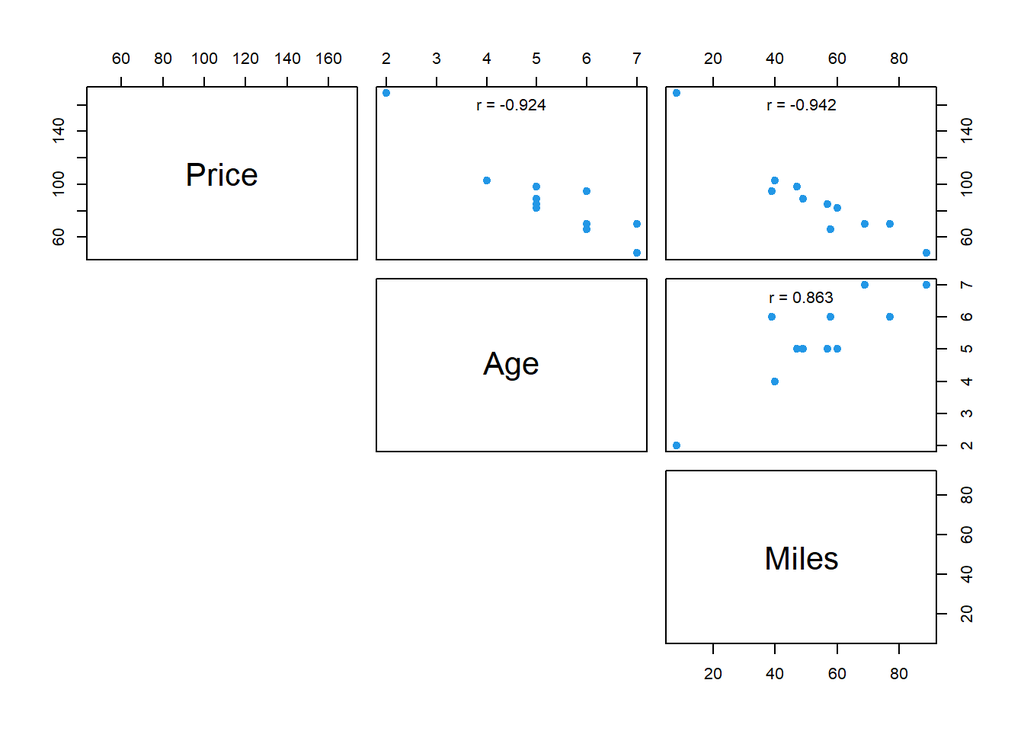

## Coefficient of determination, $R^2$ and adjusted $R^2$

- Recall that, $R^2$ is a measure of the proportion of the total variation in the observed values of the response variable that is explained by the multiple linear regression in the $k$ predictor variables $x_1, x_2, \ldots, x_k$.
- $R^2$ will increase when an additional predictor variable is added to the model. One should not simply select a model with many predictor variables because it has the highest $R^2$ value, it is often good to have a model with high $R^2$ value but only few x’s included.
- Adjusted $R^2$ is a modification of $R^2$ that takes into account the number of predictor variables.
  $$\mbox{Adjusted-}R^2=1-(1-R^2)\frac{n-1}{n-k-1}$$

## The residual standard error, $s_e$

- Recall that,
  $$\text{Residual} =
  \text{Observed value} - \text{Predicted value.}$$

$$e_i=y_i-\hat{y}_i$$

- In a multiple linear regression with $k$ predictors, the standard error of the estimate, $s_e$, is defined by
  $$s_e=\sqrt{\frac{SSE}{n-(k+1)}}\;\;\;\;\;
  \text{where}\;\;SSE=\sum (y_i-\hat{y}_i)^2$$
- The standard error of the estimate, $s_e$, indicates how much, on average, the observed values of the response variable differ from the predicated values of the response variable. The $s_e$ is the estimate of the common standard deviation $\sigma$.

## Inferences about a particular predictor variable

- To test whether a particular predictor variable, say $x_i$, is useful for predicting $y$ we test the null hypothesis $H_0:\beta_i=0$ against $H_1:\beta_i\neq 0$.
- The test statistic
  $$t=\frac{b_i}{s_{b_i}}$$
  has a $t$-distribution with degrees of freedom $df=n-(k+1)$. So we reject $H_0$, at level $\alpha$, if $|t|>t_{\alpha/2}.$
- Rejection of the null hypothesis indicates that $x_i$ is useful as a predictor for $y$. However, failing to reject the null hypothesis suggests that $x_i$ may not be useful as a predictor of $y$, so we may want to consider removing this variable from the regression analysis.
- 100(1-$\alpha$)% confidence interval for $\beta_i$ is
  $$b_i \pm t_{\alpha/2} . s_{b_i}$$
  where $s_{b_i}$ is the standard error of $b_i$.

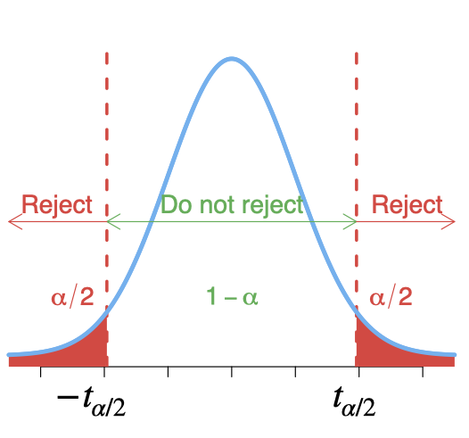

## How useful is the multiple regression model?

**Goodness of fit test**

To test how useful is this model, we test the null hypothesis

$H_0: \beta_1=\beta_2=\ldots =\beta_k=0$, against

$H_1: \text{at least one of the} \;\beta_i \text{'s is not zero}$. - The $F$-statistic
$$F=\frac{MSR}{MSE}=\frac{SSR/k}{SSE/(n-k-1)}$$
with degrees of freedom $df_1=k$ and $df_2=n-(k+1)$.

We reject $H_0$, at level $\alpha$, if $F>F_{\alpha}(df_1,df_2)$.

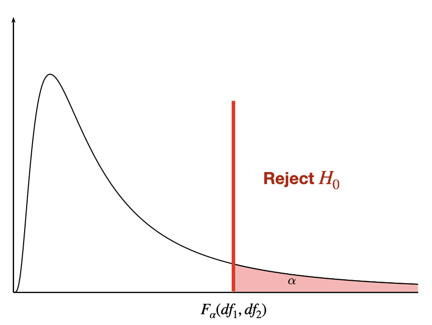

## Used cars example continued

Multiple regression equation: $\hat{y}=183.04-9.50 x_1- 0.82 x_2$

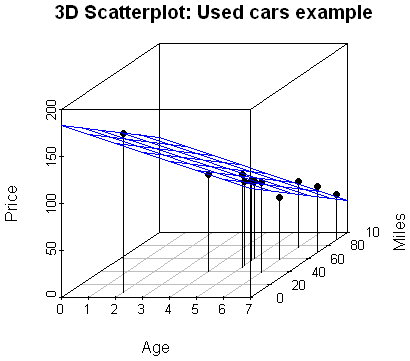

The predicted price for a 4-year-old car that has driven 45 thousands miles is
$$\hat{y}=183.04-9.50 (4)- 0.82
(45)=108.14$$
(as units of $100 were used, this means $10814)

**Extrapolation:** we need to look at the region (all combined values) not only the range of the observed values of each predictor variable separately.

## Regression in R

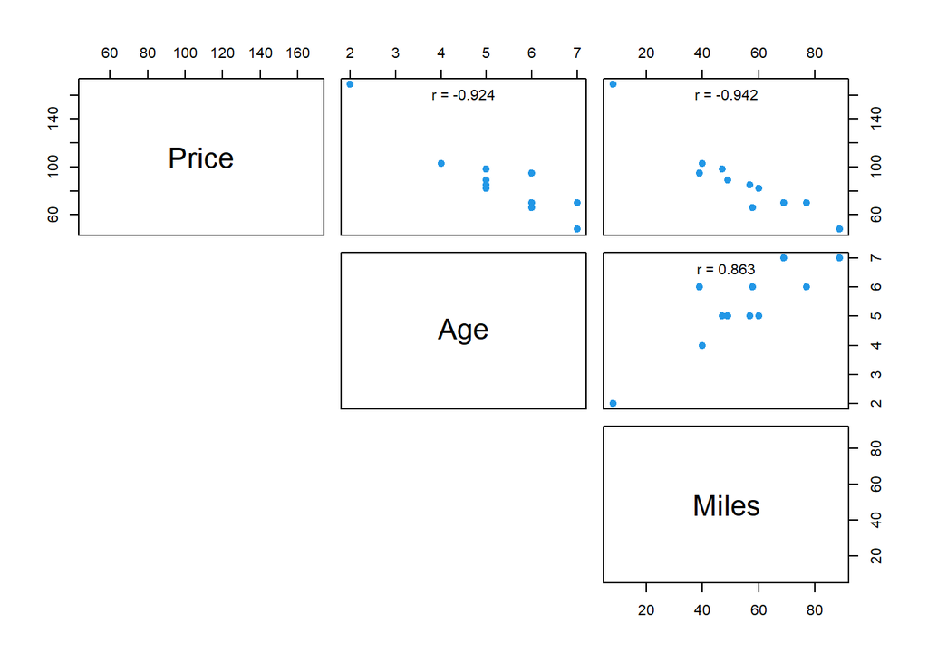

```r
Price<-c(85, 103,  70,  82,  89,  98,  66,  95, 169,  70,  48)
Age<- c(5, 4, 6, 5, 5, 5, 6, 6, 2, 7, 7)
Miles<-c(57,40,77,60,49,47,58,39,8,69,89)
carSales<-data.frame(Price=Price,Age=Age,Miles=Miles)


# Scatterplot matrix
# Customize upper panel
upper.panel<-function(x, y){
  points(x,y, pch=19, col=4)
  r <- round(cor(x, y), digits=3)
  txt <- paste0("r = ", r)
  usr <- par("usr"); on.exit(par(usr))
  par(usr = c(0, 1, 0, 1))
  text(0.5, 0.9, txt)
}
pairs(carSales, lower.panel = NULL,
      upper.panel = upper.panel)
```

```r
reg <- lm(Price~Age+Miles,data=carSales)
summary(reg)
```

```
##
## Call:
## lm(formula = Price ~ Age + Miles, data = carSales)
##
## Residuals:
##     Min      1Q  Median      3Q     Max
## -12.364  -5.243   1.028   5.926  11.545
##
## Coefficients:
##             Estimate Std. Error t value Pr(>|t|)
## (Intercept) 183.0352    11.3476  16.130 2.19e-07 ***
## Age          -9.5043     3.8742  -2.453   0.0397 *
## Miles        -0.8215     0.2552  -3.219   0.0123 *
## ---
## Signif. codes:  0 '***' 0.001 '**' 0.01 '*' 0.05 '.' 0.1 ' ' 1
##
## Residual standard error: 8.805 on 8 degrees of freedom
## Multiple R-squared:  0.9361, Adjusted R-squared:  0.9201
## F-statistic: 58.61 on 2 and 8 DF,  p-value: 1.666e-05
```

```r
confint(reg, level=0.95)
```

```
##                  2.5 %      97.5 %
## (Intercept) 156.867552 209.2028630
## Age         -18.438166  -0.5703751
## Miles        -1.409991  -0.2329757
```

### Summary

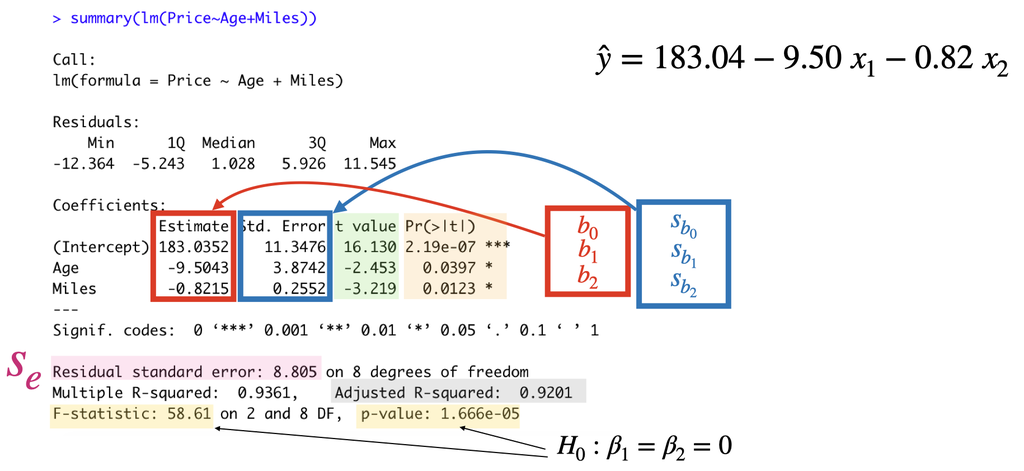

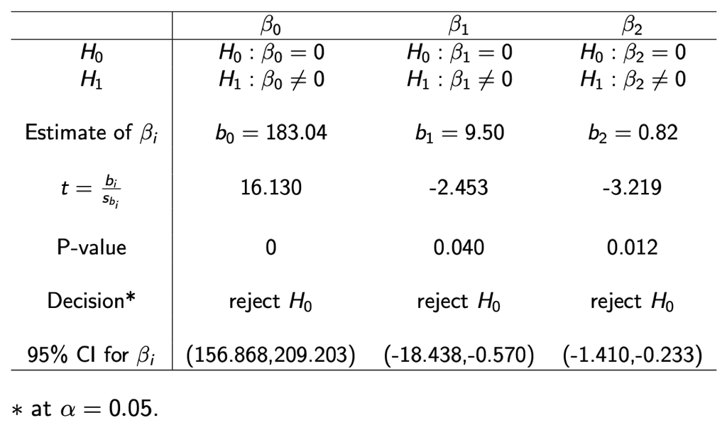

## Multiple Linear Regression Assumptions

- **Linearity**: For each set of values, $x_1, x_2, \ldots, x_k$, of the predictor variables, the conditional mean of the response variable $y$ is $\beta_0+\beta_1 x_1+\beta_2 x_2+ \ldots+ \beta_k x_k$.
- **Equal variance (homoscedasticity)**: The conditional variance of the response variable are the same (equal to $\sigma^2$) for all sets of values, $x_1, x_2, \ldots, x_k$, of the predictor variables.
- **Independent observations**: The observations of the response variable are independent of one another.
- **Normally**: For each set values, $x_1, x_2, \ldots, x_k$, of the predictor variables, the conditional distribution of the response variable is a normal distribution.
- **No Multicollinearity**: Multicollinearity exists when two or more of the predictor variables are highly correlated.

### Multicollinearity

- Multicollinearity refers to a situation when two or more predictor variables in our multiple regression model are highly (linearly) correlated.
- The least square estimates will remain unbiased, but unstable.
- The standard errors (of the affected variables) are likely to be high.
- Overall model fit (e.g. R-square, F, prediction) is not affected.

### Multicollinearity: Detect

- Scatterplot Matrix
- **Variance Inflation Factors**: the Variance Inflation Factors (VIF) for the $i^{th}$ predictor is
  $$VIF_i=\frac{1}{1-R^2_i}$$
  where $R^2_i$ is the R-square value obtained by regressing the $i^{th}$ predictor on the other predictor variables.
- $VIF=1$ indicates that there is no correlation between $i^{th}$ predictor variable and the other predictor variables.
- As rule of thumb if $VIF>10$ then multicollinearity could be a problem.

### Multicollinearity: How to fix?

**Ignore:** if the model is going to be used for prediction only.

**Remove:** e.g. see if the variables are providing the same information.

**Combine:** combining highly correlated variables.

**Advanced:** e.g. Principal Components Analysis, Partial Least Squares.

$~$

## Regression in R (regression assumptions)

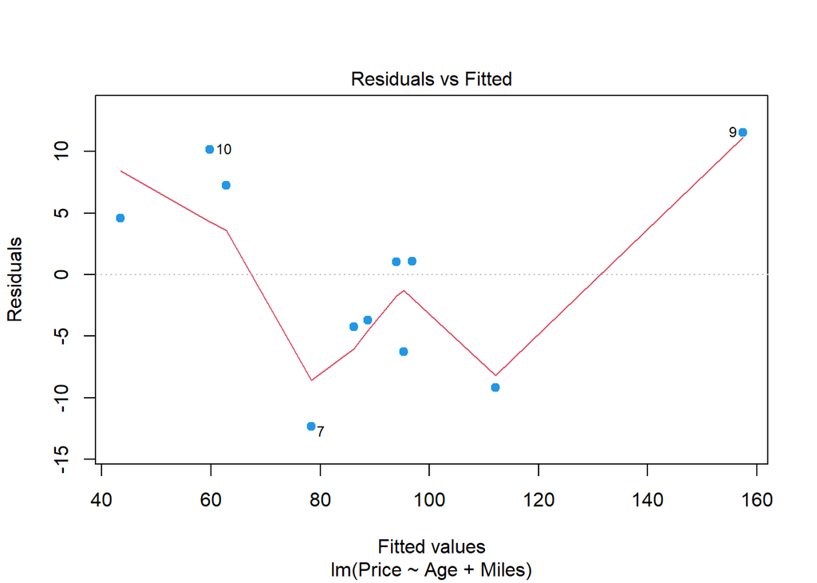

```r
plot(reg, which=1, pch=19, col=4)
```

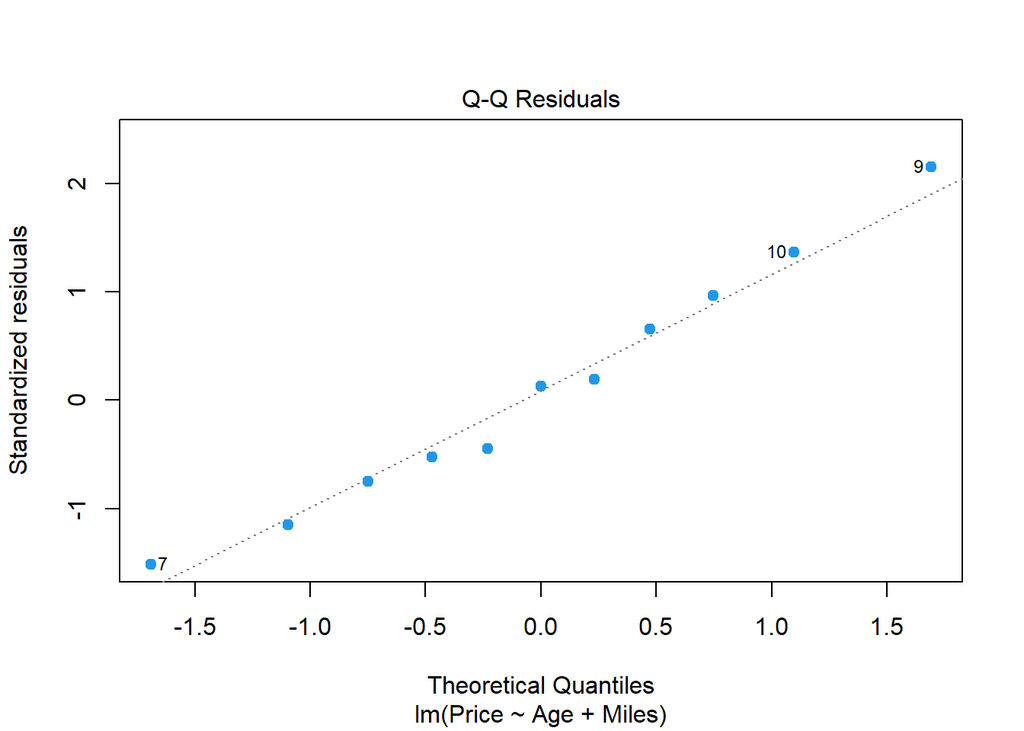

```r
plot(reg, which=2, pch=19, col=4)
```

```r
# install.packages("car")
library(car)
vif(reg)
```

```
##      Age    Miles
## 3.907129 3.907129
```

The value of $VIF=3.91$ indicates a moderate correlation between the age and the miles in the model, but this is not a major concern.